# Firearm Murders

Josue Perez Gomez

12/14/2019

## Loading the Libararies

```r
# clean up workspace environment
rm(list = ls())
# all packages used for the assignment
library(mosaic)
library(tidyverse)
library(DataComputing)
library(dplyr)
library(lubridate)
library(party)
```

## Purpose

**The purpose of this project is evaluate and examine the number of murders by firearms on different states and years in the US. As well as to compare them with the level of unemployement in those states during those years. Trying to solve the question of does higer unemployment leads to highes murders by firearms, this is done so we can propose solutions to murders.**

## Data Access

```r
FirearmMurdersData <- read.csv(file = "Firearm Murders.csv", stringsAsFactors = F)
str(FirearmMurdersData)
```

```
'data.frame':   2632 obs. of  6 variables:
 $ Year               : int  1991 1991 1991 1991 1992 1992 1992 1992 1993 1993 ...
 $ State              : chr  "National" "National" "National" "National" ...
 $ Total              : int  14373 14373 14373 14373 15489 15489 15489 15489 16136 16136 ...
 $ Total.minus.Unknown: int  13366 13366 13366 13366 14397 14397 14397 14397 15026 15026 ...
 $ Type               : chr  "Handguns" "Rifles" "Shotguns" "Unknown" ...
 $ By.Type            : int  11497 745 1124 1007 12580 706 1111 1092 13212 757 ...
```

```r
glimpse(FirearmMurdersData)
```

```
Observations: 2,632
Variables: 6
$ Year                <int> 1991, 1991, 1991, 1991, 1992, 1992, 1992, 1992, 1993, 1993, 1993, 1993, 199…
$ State               <chr> "National", "National", "National", "National", "National", "National", "Na…
$ Total               <int> 14373, 14373, 14373, 14373, 15489, 15489, 15489, 15489, 16136, 16136, 16136…
$ Total.minus.Unknown <int> 13366, 13366, 13366, 13366, 14397, 14397, 14397, 14397, 15026, 15026, 15026…
$ Type                <chr> "Handguns", "Rifles", "Shotguns", "Unknown", "Handguns", "Rifles", "Shotgun…
$ By.Type             <int> 11497, 745, 1124, 1007, 12580, 706, 1111, 1092, 13212, 757, 1057, 1110, 127…
```

```r
head(FirearmMurdersData, 10)
```

|  | Year | State | Total | Total.minus.Unknown | Type | By.Type |
| --- | --- | --- | --- | --- | --- | --- |
| 1 | 1991 | National | 14373 | 13366 | Handguns | 11497 |
| 2 | 1991 | National | 14373 | 13366 | Rifles | 745 |
| 3 | 1991 | National | 14373 | 13366 | Shotguns | 1124 |
| 4 | 1991 | National | 14373 | 13366 | Unknown | 1007 |
| 5 | 1992 | National | 15489 | 14397 | Handguns | 12580 |
| 6 | 1992 | National | 15489 | 14397 | Rifles | 706 |
| 7 | 1992 | National | 15489 | 14397 | Shotguns | 1111 |
| 8 | 1992 | National | 15489 | 14397 | Unknown | 1092 |
| 9 | 1993 | National | 16136 | 15026 | Handguns | 13212 |
| 10 | 1993 | National | 16136 | 15026 | Rifles | 757 |

```r
tail(FirearmMurdersData)
```

|  | Year | State | Total | Total.minus.Unknown | Type | By.Type |
| --- | --- | --- | --- | --- | --- | --- |
| 2627 | 2016 | Wisconsin | 166 | 129 | Shotgun | 4 |
| 2628 | 2016 | Wisconsin | 166 | 129 | Unknown | 37 |
| 2629 | 2016 | Wyoming | 6 | 2 | Handgun | 1 |
| 2630 | 2016 | Wyoming | 6 | 2 | Rifle | 0 |
| 2631 | 2016 | Wyoming | 6 | 2 | Shotgun | 1 |
| 2632 | 2016 | Wyoming | 6 | 2 | Unknown | 4 |

```r
names(FirearmMurdersData)
```

```
[1] "Year"                "State"               "Total"               "Total.minus.Unknown"
[5] "Type"                "By.Type"
```

```r
nrow(FirearmMurdersData)
```

```
[1] 2632
```

```r
ncol(FirearmMurdersData)
```

```
[1] 6
```

```r
UnemploymentData <- read.csv(file = "UnemploymentPercent.csv", stringsAsFactors = F)
```

### Modifying Elements in the Data

```r
FirearmMurdersData$Type = as.factor(FirearmMurdersData$Type)
levels(FirearmMurdersData$Type) <- c("Handgun", "Handgun", "Rifle","Rifle", "Shotgun","Shotgun", "Unknown")
FirearmMurdersData$Type = as.character(FirearmMurdersData$Type)
```

# Data Wrangling

### Finding Murder Number per Type in Pennsylvania

```r
FirearmMurdersData %>%
  filter(State == "Pennsylvania") %>%
  group_by(State, Type) %>%
  summarise(total = sum(Total)) %>%
  arrange(desc(total))
```

| State | Type | total |
| --- | --- | --- |
| Pennsylvania | Handgun | 6372 |
| Pennsylvania | Rifle | 6372 |
| Pennsylvania | Shotgun | 6372 |
| Pennsylvania | Unknown | 6372 |

### Finding The Average Number of Murders for All the States (Per Year)

```r
FirearmMurdersData %>%
  select(State, Type, Total, Year) %>%
  filter(State != "National") %>%
  group_by(State) %>%
  summarise(average = mean(Total)) %>%
  arrange(desc(average))
```

| State | average |
| --- | --- |
| California | 1435.384615 |
| Texas | 863.538462 |
| Pennsylvania | 490.153846 |
| New York | 437.000000 |
| Michigan | 434.153846 |
| Illinois | 413.230769 |
| Georgia | 412.461538 |
| Louisiana | 379.615385 |
| North Carolina | 336.769231 |
| Maryland | 323.384615 |

[output cut: 43 more lines]

**Here we found that the state of California was the state with the highest average firearm murders per year.**

### Modifying the data to have only known of firearm and by state

```r
KnownFireArmMurders <- FirearmMurdersData %>%
  filter(State != "National" & Type != "Unknown")
```

### Joining Tables

```r
#Modifying Original Data Set
AverageUnemployment <- UnemploymentData %>%
  filter(Year > 2003) %>%
  group_by(Year,State) %>%
  select(Year, State, Rate) %>%
  dplyr::summarise(UnEmpRate = mean(Rate))

#Joining by Year and State
CombinedData <- KnownFireArmMurders %>%
  dplyr::inner_join(AverageUnemployment)
```

### Finding the Years and States that had the Highest UnEmployment Rate

```r
CombinedData %>%
  select(State, Year, UnEmpRate) %>%
  group_by(State) %>%
  dplyr::summarise(average = mean(UnEmpRate)) %>%
  arrange(desc(average)) %>%
  head(10)
```

| State | average |
| --- | --- |
| California | 9.311294 |
| Arizona | 9.169744 |
| South Carolina | 9.155923 |
| Michigan | 9.115187 |
| Mississippi | 8.965314 |
| Oregon | 8.204345 |
| Tennessee | 8.046606 |
| Washington | 7.973800 |
| North Carolina | 7.803545 |
| Kentucky | 7.795787 |

**The data frame above we can see that California, Arizona, South Carolina, etc… to have been the states with the highest unemployment percentages**

### Finding the Years and States that had the Lowest Unemployment Rate

```r
CombinedData %>%
  select(State, Year, UnEmpRate) %>%
  group_by(State) %>%
  dplyr::summarise(average = mean(UnEmpRate)) %>%
  arrange(desc(average)) %>%
  tail(10)
```

| State | average |
| --- | --- |
| Hawaii | 5.120833 |
| Montana | 5.100069 |
| Vermont | 4.749206 |
| Iowa | 4.698893 |
| Kansas | 4.593132 |
| Wyoming | 4.469008 |
| New Hampshire | 4.294103 |
| South Dakota | 4.250039 |
| North Dakota | 3.726468 |
| Nebraska | 3.469582 |

**The data frame shows that states such as Hawaii, Montana, Vermont, etc… to have the lowest unemployment percentages.**

### Creating a function that automates gather the average number of murders from two given states for a set of years

```r
getComparation <- function(name,Name, from, to)
{

ComparedStates <- CombinedData %>%
  filter(State == c(name, Name))
  averages <- tibble(length = to-from)
  for (i in from:to) {
   averages[i-(from-1)] = ComparedStates %>%
      filter(Year == i) %>%
      dplyr::summarise(average = mean(Total))


  }
  print(averages)
  rm(ComparedStates, averages)
}
getComparation("Alabama","Texas", 2007,2016)
```

| length | average | average.1 | average.2 | average.3 | average.4 | average.5 | average.6 | average.7 | average.8 |
| --- | --- | --- | --- | --- | --- | --- | --- | --- | --- |
| 725.6667 | 262 | 229 | 470 | 699 | 745 | 760 | 765 | 906 | 1066 |

# Data Visualization

### Descicion Tree

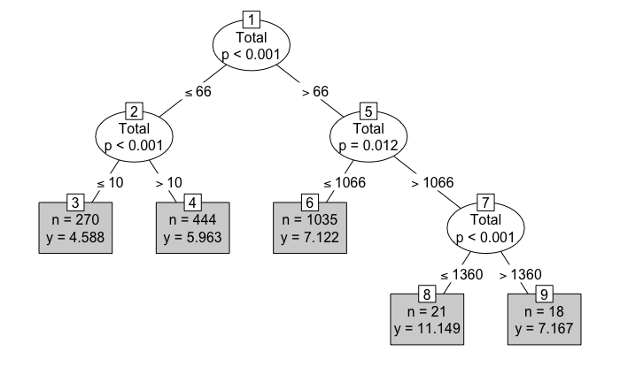

```r
mod2 <- party::ctree(
  UnEmpRate ~ By.Type + Total,
  data = CombinedData
)
plot(mod2,type = "simple")
```

**Here the descicion tree shows predicting unemployment rate based on the number of murders done by type and the total of the murders done by firearms.**

### General Scatter Plot

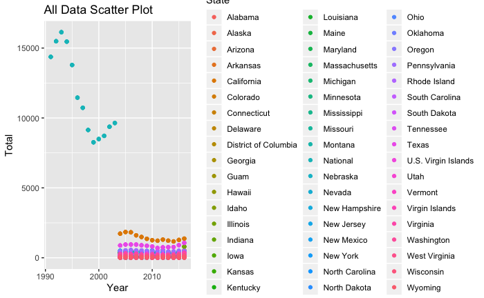

```r
FirearmMurdersData %>%
  ggplot(aes(x = Year, y = Total)) +
  geom_point() +
  labs(title = "All Data Scatter Plot") +
  aes(colour = State)
```

**Above a graph containing the total number of murders each year, colored by the each state (including National) When can see where the state record data recordings starts and where the National data recordings end.**

### The Density of the Number of States Based on the Unemployment Rate

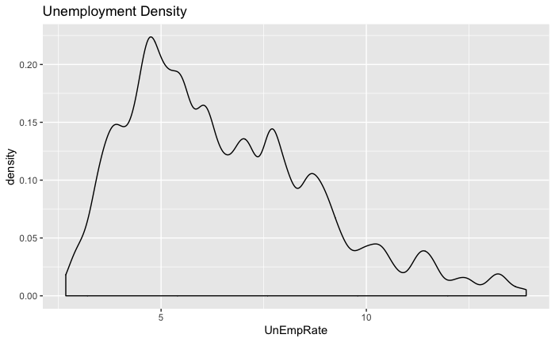

```r
AverageUnemployment %>%
  ggplot(aes(x = UnEmpRate)) +
  geom_density(adjust = 0.34) +
  aes(fill = UnEmpRate) +
  labs(title = "Unemployment Density") +
  theme(legend.position = "right")
```

**Based on this density graph we can observe that the density of most states fall under low unemployment rate,**

### Boxplot of the number of murders done by the known type of weapon

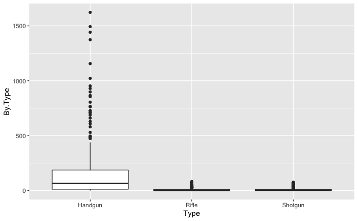

```r
KnownFireArmMurders %>%
  ggplot(aes(x = Type, y = By.Type)) +
  geom_boxplot()
```

```r
NA
```

**On the graph above we can see through a boxplot the type of known firearms, and from the boxplot we can see that in fact murders comitted with handguns are the more predominant**

### Gathering from Murders from Pennsylvania

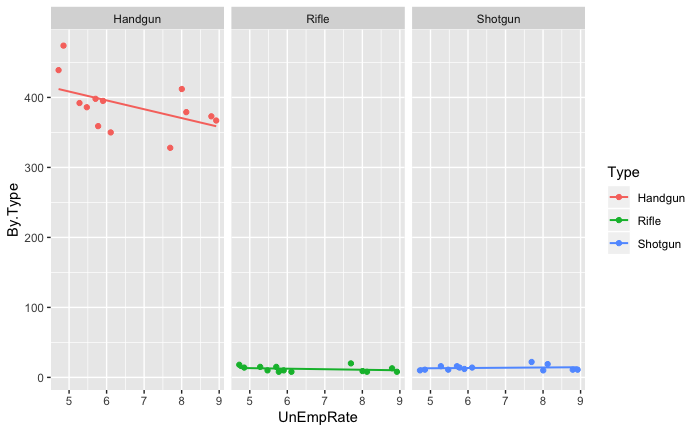

```r
PennsylvaniaMurders <- CombinedData %>%
  filter(State == "Pennsylvania")
PennsylvaniaMurders %>%
  ggplot(aes(x = UnEmpRate, y = By.Type)) +
  geom_point() +
  aes(colour = Type) +
  geom_lm() +
  facet_wrap(~Type, ncol =4)
```

```r
NA
```

**On the graph above it is shown how the number of murders have deacresed for handguns while for the rest it has been flat. However this deacreases when the unemployment rate grows.**